# Transcription and Splicing Dynamics

Edward Wallace, ewjwallace@gmail.com

11th January 2018

This document uses a simple first-order model of transcription, splicing, and decay, to ask what changes in transcription and splicing rate we could reasonably detect. It concludes that the fraction unspliced should be a good way to detect changes in splicing rate.

I wrote this in 2017 to clarify some discussions in the Beggs lab, and shared it on github in 2018. Please let me know if you find it interesting or useful.

## The model

Pre-mRNA (P) is **transcribed** at rate $\tau$, **spliced** at rate $\sigma$ to mRNA (M), which is then **degraded** at rate $\lambda$. As usual in these models, $\phi$ is used as a placeholder for emptiness - creation or decay.

$$\phi \xrightarrow{\tau} P \xrightarrow{\sigma} M \xrightarrow{\lambda} \phi$$

In differential equations,

$$\frac{dP}{dt} = \tau - \sigma P$$

$$\frac{dM}{dt} = \sigma P - \lambda M$$

This model **ignores** degradation of pre-mRNA.

### Simulate from model

Here we simulate using the exact analytical solution of the simple model.

We use $\tau=1$, $\sigma=1$, $\lambda=0.1$. I.E. rate of splicing per pre-mRNA molecule is 10X rate of decay per mRNA.

We start with initial conditions $P=0$, $M=0$, which approximates a perfect pulse-labeling experiment, for example with 4tU.

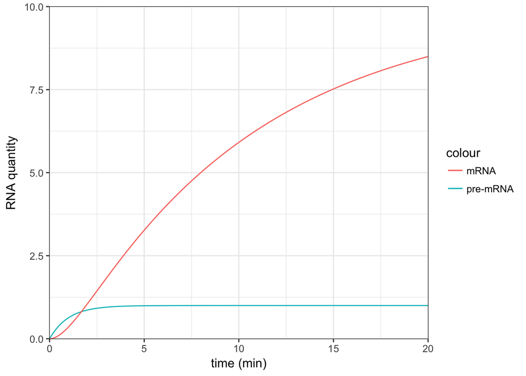

### Vary transcription and splicing rate

Here with varying $\tau$ and $\sigma$, keeping fixed $\lambda=0.1$.

This shows that the amount of pre-mRNA rapidly converges to the expected steady-state value of $\tau/\sigma$, and the amount of mRNA more slowly converges to $\tau/\lambda$.

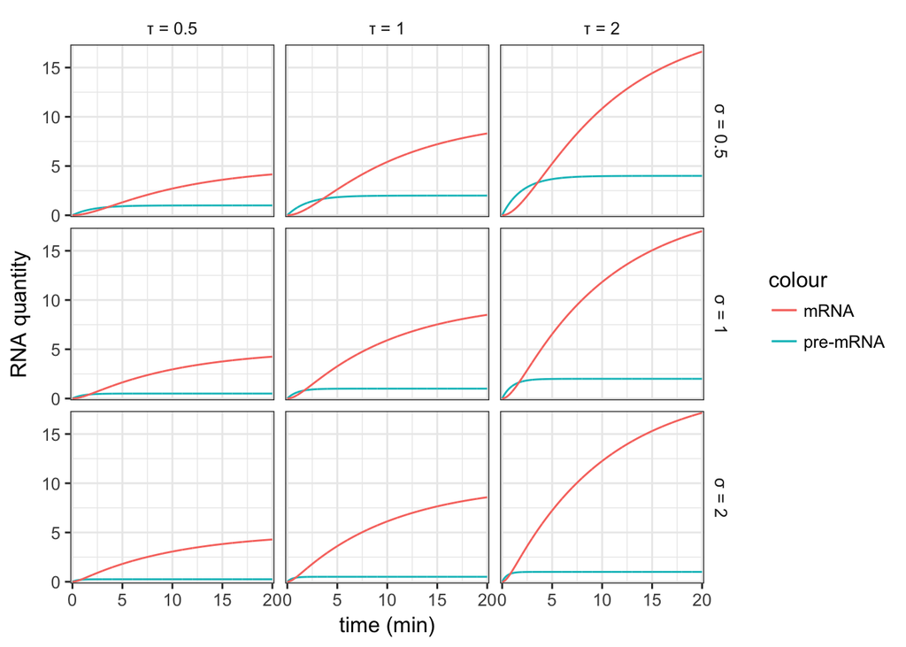

### Zooming in on initial 5 minutes

We zoom in on the initial times to see changes from varying transcription and splicing rate. Same curves as above, varying $\tau$ and $\sigma$, keeping fixed $\lambda=0.1$.

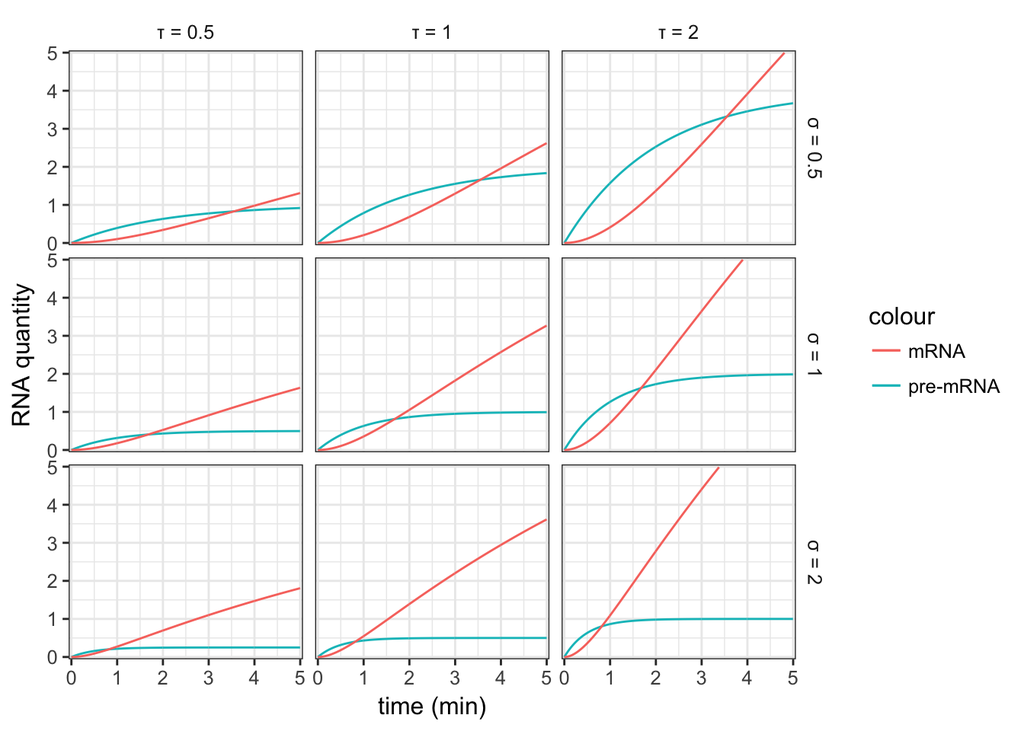

### The pre-mRNA level alone barely distinguishes splicing rate from transcription rate

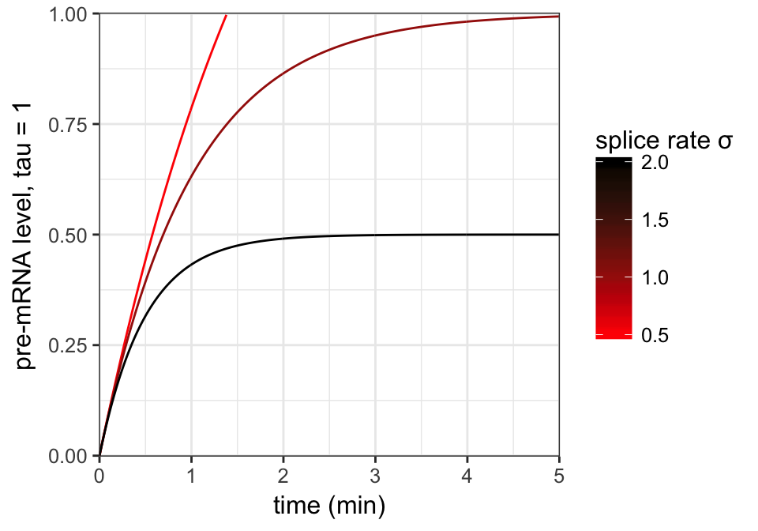

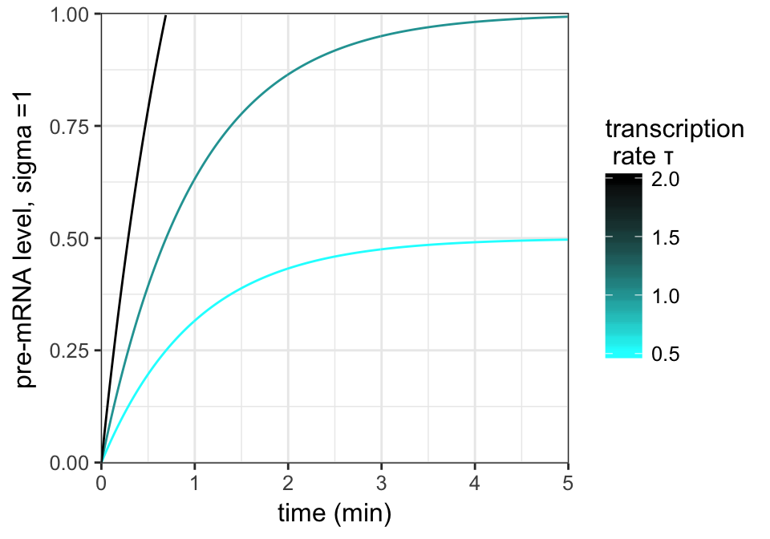

Because changing the splicing rate changes the rate of approach to steady-state, in principle we could detect this with a fast enough time-course.

### Fraction unspliced detects the splicing rate

Again with varying $\tau$ and $\sigma$, keeping fixed $\lambda=0.1$.

In this model, the unspliced/total ratio is **independent** of transcription rate $\tau$.

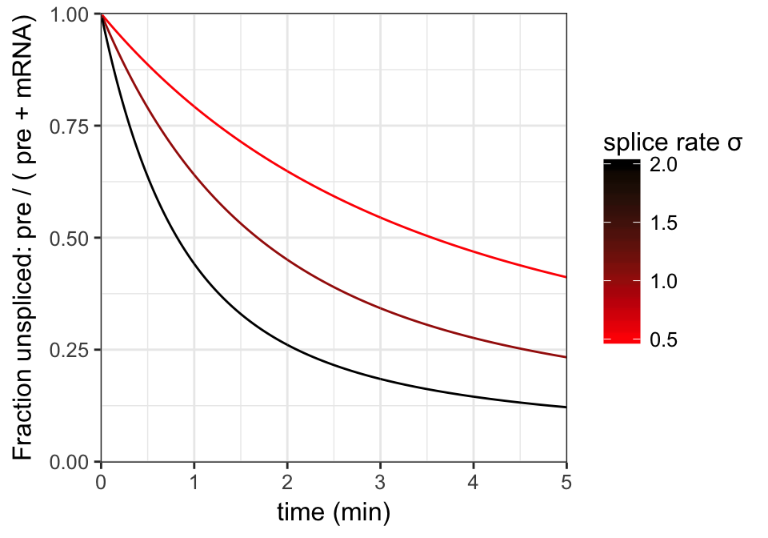

### Initial fraction unspliced is not very sensitive to changes in mRNA decay rate

Here varying $\sigma$ and $\lambda$, keeping fixed transcription rate $\tau=1$.

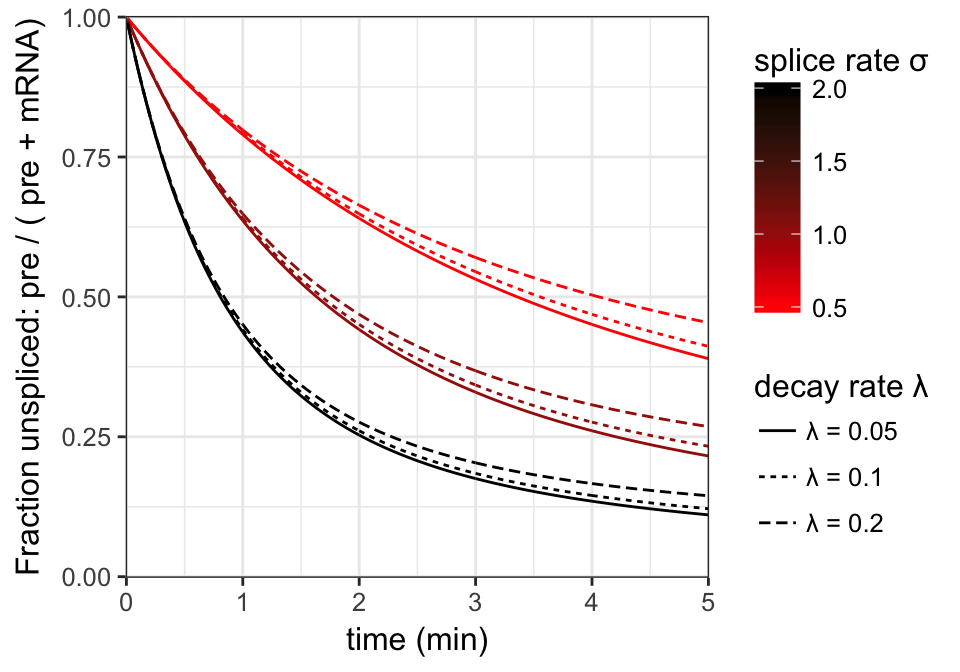

This point applies to the initial part of the timecourse, which we could detect by pulse-labeling. The same approach shows that, if mRNA splicing rate were constant and mRNA decay rate variable, then **steady-state** fraction unspliced would be a good proxy for decay rate. I heard this point made by Uwe Ohler at a conference in 2015.

## Conclusion

I conclude that the fraction unspliced should be a good measure of splicing rate as opposed to transcription, as long as

- the first-order model is close enough to reality
- background is low (we did not check this directly, yet)
- mature mRNA decay rate is much less than splicing rate and does not vary much (2x is ok)

#### Acknowledgments

Thanks to Guido Sanguinetti, Jean Beggs, and David Barrass for discussions.